# ML Tutorial by

### Lydia Gu, David Kellogg, Arsen Mamikonyan

Using scikit-learn and ipython notebook

## What is Machine Learning ??

Combine

- (a lot of data)
- mathematics (and computational power)

#### Machine learning explores the construction and study of algorithms that can learn from and make predictions on data.

> Ron Kohavi; Foster Provost (1998). "Glossary of terms". Machine Learning 30: 271–274.

## Some Machine Learning Examples

##### Machine Learning example 1

### Facebooks personalizes your newsfeed based on your likes and clicks

[figure not shown]

##### Machine Learning example 2

### Netflix shows you suggestions based on what you have watched and other netflix users have watched

[figure not shown]

##### Machine Learning example 3

### Siri

[figure not shown]

### Supervised vs. Unsupervised Learning

#### Supervised Learning

[figure not shown]

- We have data mapping a set of inputs to a set of outputs (the labels). We use this labelled data to develop a model that can take new unseen inputs and predict the output.

#### Unsupervised Learning

[figure not shown]

- We have a set of data, but no labels. We want to find some hidden structure in the data.

## Supervised Learning

- Labeled data (to learn on)
- Unlabeled data (to answer our question for)

### Classification vs Regression

#### Regression

- labels are continuous
  - what will be stock pice (tomorrow after closing)
  - temperature in Phoenix (tomorrow at noon)

#### Classification

- labels are categorical
  - Which will be the best talk at the Techfest?
  - Will there be a good vegeterian option at lunch?

Regression

Classification

[figure not shown]

- Citation: http://ipythonbooks.github.io/featured04/

## Unsupervised Learning

We have

- only unlabbeled data

Goal

- deduce some structure of the data and predict (is this true?) based on that data

#### Examples

- clustering
- density estimation
- dimension reduction
- principle components?
- manifold learning (nonlinear dimension reduction)

## This tutorial

- We will spend most of the tutorial talking about supervised learning methods.
- We will be using the Python library scikit-learn to work through some examples. Scikit-learn is a collection of useful machine learning tools, from the models themselves to tools for cleaning data and evaluating models.

## How is ML done

[figure not shown]

1. Get data
2. Clean data
3. Data Transformation (feature engineering)
4. Fitting a model (Data Mining)
5. Predicting
6. Deploying the model

### We will focus

1. Get data
2. Clean data
3. **Data Transformation (feature engineering)**
4. **Fit a model (Data Mining)**
5. **Predicting**
6. Deploying the model

## Data Transformation (Feature Engineering)

[figure not shown]

->

[figure not shown]

### Why can't we use original data?

- It could be **scattered**. We need to **consolidate** the data
- computer can't interpret the raw data. We have to guide it, transform the data into machine understandable format (construct features)

## Training a model

- A [mathematical] **Model** is the algorithm that we want to use to predict
- To generalize data we break up the data into training and test sets
- The training set is used to train the model, and the test set is used to evaluate the model performance on unseen data.

## scikit-learn example

```python
from sklearn import svm
from sklearn import datasets

clf = svm.SVC(gamma=0.001, C=100.)
digits = datasets.load_digits()
```

```python
clf = clf.fit(digits.data[:-1], digits.target[:-1])
clf.predict(digits.data[-1])
```

```
array([8])
```

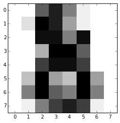

```python
%matplotlib inline
import matplotlib.pyplot as plt
plt.imshow(digits.images[-1], cmap=plt.cm.gray_r, interpolation='nearest')
```

## Evaluation/Chosing a model

- differnt types of models are designed to work better with different types of problems / different types of data
- We want to "simulate" predicting with classifier as close as to a real world situation when evaluating the classifier
- We randomly split training data into train/test and use test to evaluate

## Cross validation

```python
from sklearn.cross_validation import train_test_split
data_train, data_test, targets_train, targets_test = train_test_split(digits.data, digits.target, test_size=0.2)
```

### Assessing the Predictive Power of a Model

### Classification metrics

- accuracy
- precision
- recall
- f1, roc auc

## Overfitting, Underfitting and Bias vs. Variance